BIF-7900 · Bioinformatique I · Visualisation avec R

# Solutionnaire du TP3

# À votre tour

## 0. Importer

```r
library(tidyverse)
library(ggrepel)
library(pheatmap)
de  <- read_csv("/home/public/visu/de_resultats.csv")
tpm <- read_csv("/home/public/visu/tpm.csv")
```

```r
nrow(de)
```

```
#> [1] 19320
```

```r
sum(is.na(de$padj))
```

```
#> [1] 6308
```

```r
sum(de$padj < 0.05, na.rm = TRUE)
```

```
#> [1] 361
```

19320 gènes, dont 6308 **non testés** (`padj` manquante : trop peu exprimés), et 361 significatifs au seuil de 5 % (FDR). Sans `na.rm = TRUE`, la somme vaudrait `NA`.

## 1. L’histogramme des p-values

```
#> Warning: Removed 2073 rows containing non-finite outside the scale range
#> (`stat_bin()`).
```

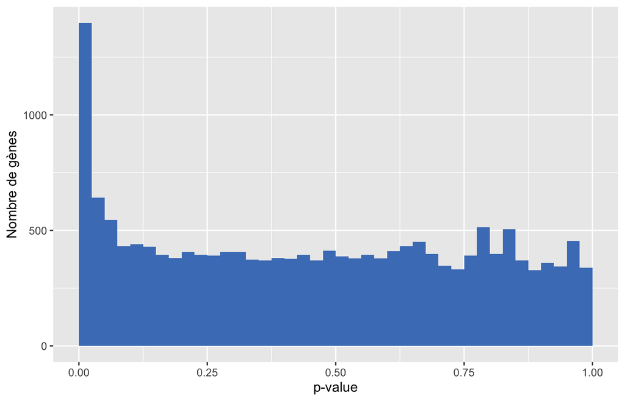

```r
ggplot(de, aes(pvalue)) +
  geom_histogram(binwidth = 0.025, boundary = 0, fill = "#4A7FC1") +
  labs(x = "p-value", y = "Nombre de gènes")
```

Un fond à peu près **plat** (les gènes qui ne changent pas : p-values uniformes) et un **pic près de 0** (les gènes qui changent vraiment). C’est la forme attendue d’une analyse saine : un histogramme en U, ou un pic près de 1, signalerait un problème de modèle. Les 2073 `NA` de `pvalue` sont retirés, avec un *warning*.

## 2. et 3. Le volcano plot

```r
de_v <- de |>
  filter(!is.na(padj)) |>
  mutate(statut = case_when(padj < 0.05 & log2FoldChange > 1  ~ "haut",
                            padj < 0.05 & log2FoldChange < -1 ~ "bas",
                            .default = "non significatif"))
count(de_v, statut)
```

```
#> # A tibble: 3 × 2
#>   statut               n
#>   <chr>            <int>
#> 1 bas                 47
#> 2 haut                21
#> 3 non significatif 12944
```

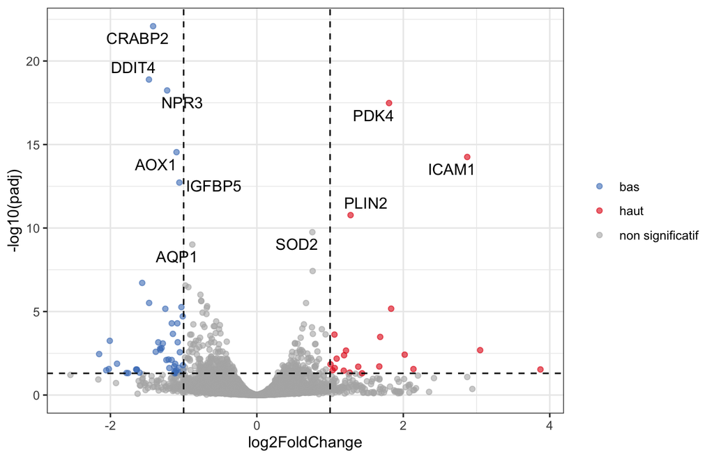

```r
top <- de_v |> slice_min(padj, n = 10)

ggplot(de_v, aes(x = log2FoldChange, y = -log10(padj), color = statut)) +
  geom_point(alpha = 0.6) +
  geom_vline(xintercept = c(-1, 1), linetype = 2) +
  geom_hline(yintercept = -log10(0.05), linetype = 2) +
  geom_text_repel(data = top, aes(label = gene), color = "black") +
  scale_color_manual(values = c(haut = "#E30513", bas = "#4A7FC1", `non significatif` = "grey70")) +
  labs(color = NULL) +
  theme_bw()
```

Seuls 68 gènes passent les **deux** seuils : la plupart des gènes significatifs changent de moins d’un facteur 2 (|log2FC| < 1). Les 10 gènes les plus significatifs ne sont pas forcément ceux qui changent le plus : `top` est choisi sur `padj`, pas sur `log2FoldChange`.

## 4. Le sens du log2FoldChange

```r
filter(de, gene == "ICAM1")
```

```
#> # A tibble: 1 × 5
#>   gene  baseMean log2FoldChange   pvalue     padj
#>   <chr>    <dbl>          <dbl>    <dbl>    <dbl>
#> 1 ICAM1     79.8           2.87 2.54e-18 5.56e-15
```

```r
filter(tpm, gene == "ICAM1")
```

```
#> # A tibble: 1 × 7
#>   gene  cond1_1 cond1_2 cond1_3 cond2_1 cond2_2 cond2_3
#>   <chr>   <dbl>   <dbl>   <dbl>   <dbl>   <dbl>   <dbl>
#> 1 ICAM1    3.48    3.79    4.55   0.432    0.64   0.506
```

`ICAM1` a un log2FoldChange de +2.87, et il est **plus exprimé dans `cond1`** (environ 4 TPM contre 0.5). Un log2FoldChange positif signifie donc ici « plus exprimé dans **cond1** que dans **cond2** » : `cond2` est la référence. Le nom des colonnes ne le dit pas : seule la vérification sur les données (ou l’en-tête des résultats de DESeq2, module 9) permet d’écrire « induit » ou « réprimé » sans se tromper de sens.

## 5. Le MA plot

```
#> Warning in scale_x_log10(): log-10 transformation introduced infinite values.
#> Warning: Removed 2071 rows containing missing values or values outside the scale range
#> (`geom_point()`).
```

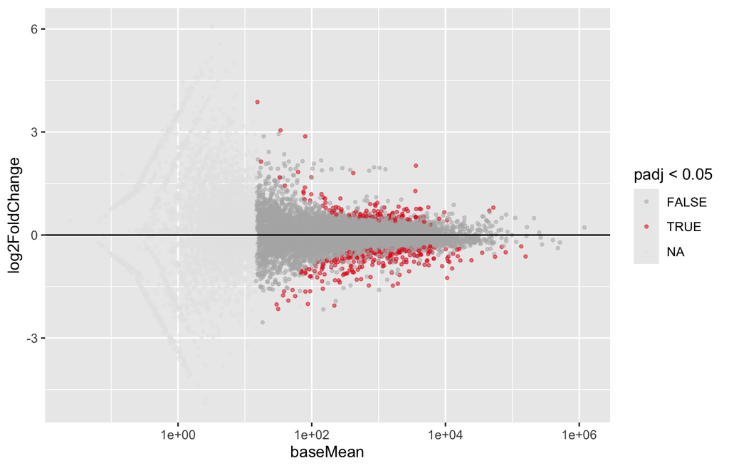

```r
ggplot(de, aes(x = baseMean, y = log2FoldChange, color = padj < 0.05)) +
  geom_point(alpha = 0.5, size = 0.8) +
  scale_x_log10() +
  geom_hline(yintercept = 0) +
  scale_color_manual(values = c(`TRUE` = "#E30513", `FALSE` = "grey70"), na.value = "grey90")
```

Les gènes peu exprimés (à gauche) ont des log2FoldChange très dispersés mais rarement significatifs : avec peu de lectures, un grand changement peut être dû au hasard. Les gènes à `baseMean` = 0 disparaissent (`log10(0) = -Inf`), avec un *warning*.

## 6. Les distributions par échantillon

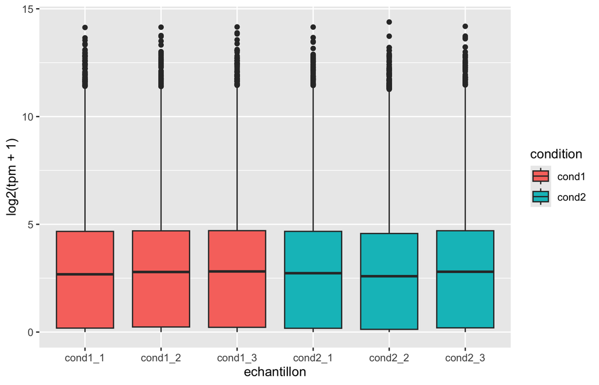

```r
tpm_long <- tpm |> pivot_longer(-gene, names_to = "echantillon", values_to = "tpm")

ggplot(tpm_long, aes(x = echantillon, y = log2(tpm + 1), fill = str_sub(echantillon, 1, 5))) +
  geom_boxplot() +
  labs(fill = "condition")
```

Les six distributions sont très proches : les échantillons sont **comparables** (même profondeur, même normalisation). Un échantillon décalé serait suspect.

## 7. La heatmap

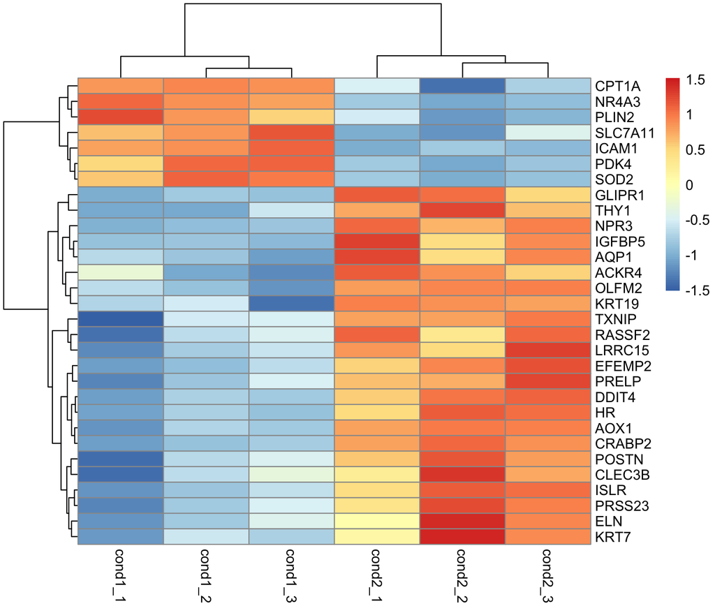

```r
genes <- de |> slice_min(padj, n = 30) |> pull(gene)
m <- tpm |>
  filter(gene %in% genes) |>
  column_to_rownames("gene") |>
  as.matrix()
pheatmap(log2(m + 1), scale = "row")
```

Les échantillons se séparent en deux groupes, **un par condition** : c’est attendu, puisqu’on a choisi les gènes qui différencient les conditions. Une heatmap de gènes sélectionnés ainsi ne « prouve » donc pas que les conditions sont différentes.

## 8. CRABP2 : barre ou points ?

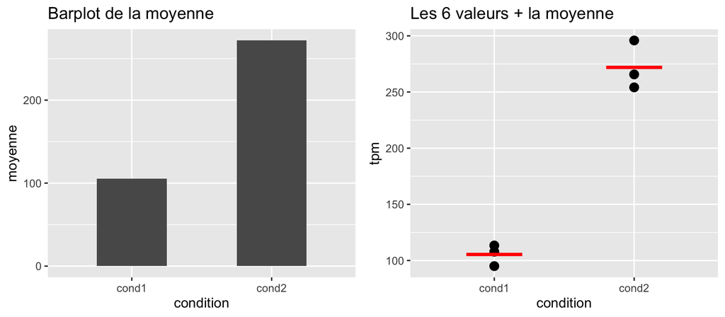

```r
crabp2 <- tpm_long |>
  filter(gene == "CRABP2") |>
  mutate(condition = str_sub(echantillon, 1, 5))

p_barre <- crabp2 |>
  summarise(moyenne = mean(tpm), .by = condition) |>
  ggplot(aes(condition, moyenne)) + geom_col(width = 0.5) + ggtitle("Barplot de la moyenne")
p_points <- ggplot(crabp2, aes(condition, tpm)) +
  geom_point(size = 3) +
  stat_summary(fun = mean, geom = "crossbar", width = 0.4, color = "red") +
  ggtitle("Les 6 valeurs + la moyenne")
gridExtra::grid.arrange(p_barre, p_points, ncol = 2)
```

Les **points** : on voit les 3 réplicats, leur dispersion, et que les deux groupes ne se chevauchent pas. Le barplot cache tout cela, et commence à 0 alors que la question porte sur l’écart entre ~100 et ~270.

# Et si… ?

## 1. `if_else()` avec les `NA`

```r
de |>
  mutate(statut = if_else(padj < 0.05, "signif", "non")) |>
  count(statut)
```

```
#> # A tibble: 3 × 2
#>   statut     n
#>   <chr>  <int>
#> 1 non    12651
#> 2 signif   361
#> 3 <NA>    6308
```

**Trois** catégories : `if_else()` renvoie `NA` quand `padj` est `NA`, et `ggplot2` en fait une catégorie grise « NA » dans la légende. Ces points ne sont d’ailleurs pas tracés sur le volcano plot (y = `-log10(NA)`), avec un *warning*. Il faut décider : retirer les gènes non testés, ou les classer explicitement.

## 2. `pvalue` ou `padj` en y

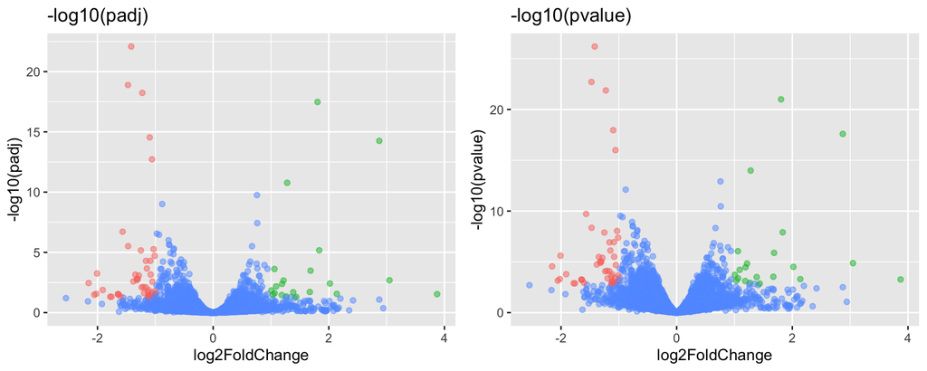

```r
g1 <- ggplot(de_v, aes(log2FoldChange, -log10(padj), color = statut)) + geom_point(alpha = 0.5) +
  theme(legend.position = "none") + ggtitle("-log10(padj)")
g2 <- ggplot(de_v, aes(log2FoldChange, -log10(pvalue), color = statut)) + geom_point(alpha = 0.5) +
  theme(legend.position = "none") + ggtitle("-log10(pvalue)")
gridExtra::grid.arrange(g1, g2, ncol = 2)
```

La forme est presque la même (`padj` est une transformation croissante de `pvalue`), mais **plus haute** avec `pvalue`. Les couleurs ne changent pas si elles sont calculées sur `padj`. En revanche, une ligne horizontale à `-log10(0.05)` sur l’axe `pvalue` ne correspond plus au seuil utilisé pour colorer : beaucoup de points gris passeraient au-dessus. Axe et seuil doivent utiliser la même colonne.

## 3. `scale_y_log10()` avec des zéros

```
#> Warning in scale_y_log10(): log-10 transformation introduced infinite values.
#> Warning: Removed 20297 rows containing non-finite outside the scale range
#> (`stat_boxplot()`).
```

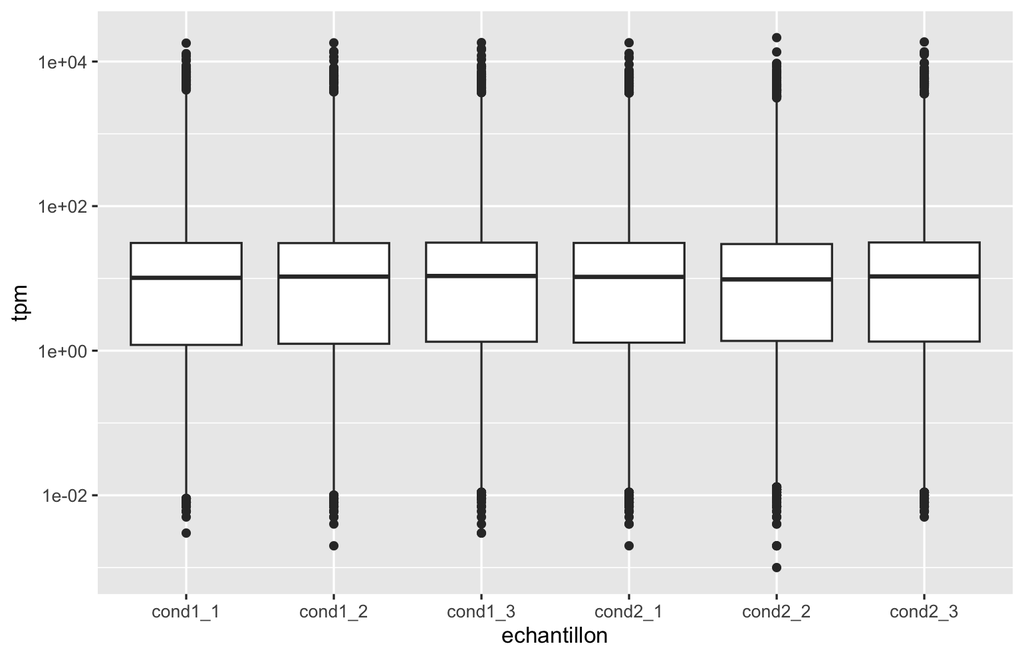

```r
ggplot(tpm_long, aes(echantillon, tpm)) +
  geom_boxplot() +
  scale_y_log10()
```

`log10(0) = -Inf` : les 20297 valeurs nulles sont **retirées** avant le calcul des boxplots (un *warning* le dit). Les médianes affichées (~10 TPM) sont celles des gènes **exprimés** seulement, deux fois plus hautes que les vraies médianes (~5.5 TPM). `log2(tpm + 1)` garde tous les gènes : un 0 devient 0.

## 4. Sans `scale = "row"`

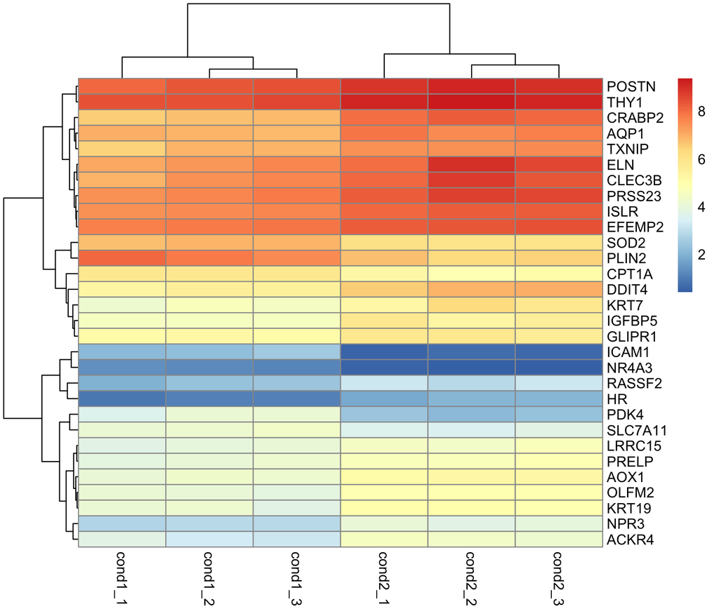

```r
pheatmap(log2(m + 1))
```

La couleur montre surtout **le niveau d’expression** de chaque gène : quelques gènes très exprimés sont rouges partout, d’autres bleus partout. Les différences **entre conditions**, qui sont la question, sont écrasées. `scale = "row"` centre et réduit chaque gène : on compare chaque échantillon à la moyenne **de ce gène**.

## 5. Rouge et vert

Environ 8 % des hommes (et 0.5 % des femmes) ont une forme de daltonisme rouge-vert : pour eux, les gènes « haut » et « bas » se confondent. Rouge et bleu, ou une palette comme `viridis` ou `scale_color_brewer(palette = "Set1")`, restent lisibles. On peut aussi doubler la couleur par la **position** (gauche/droite) ou la **forme** des points.